# Администрирование локальных сетей

Статическая маршрутизация в Интернете. (Лабораторная работа №13)

Суннатилло Махмудов

10 февраля 2026

# Цели и задачи работы

## Цель лабораторной работы

- Подготовить схему сети для организации взаимодействия через сеть провайдера
- Добавить сеть основной территории организации **42-го квартала в Москве**
- Добавить сеть филиала в **г. Сочи**
- Подготовить основу для дальнейшей настройки статической маршрутизации

# Теоретическая часть

## Статическая маршрутизация

- Маршруты задаются администратором вручную
- Используется в сетях с простой и предсказуемой топологией
- Позволяет явно определить путь передачи трафика
- Часто применяется для:
  - подключения филиалов
  - маршрута по умолчанию
  - лабораторных и учебных сетей

## Маршрутизация между VLAN

- Каждый VLAN относится к отдельной IP-подсети
- Для каждого VLAN настраивается шлюз по умолчанию
- Передача трафика между VLAN выполняется через маршрутизатор или L3-коммутатор
- Для удалённых VLAN-сетей могут использоваться статические маршруты

# Выполнение лабораторной работы

## Обновление схем L1, L2 и L3

- В схемы была добавлена информация о:
  - сети 42-го квартала в Москве
  - сети филиала в Сочи
- Изменения отражены на трёх уровнях:
  - **L1** — физические соединения
  - **L2** — VLAN
  - **L3** — IP-подсети и маршрутизация

## Схема L1: физический уровень

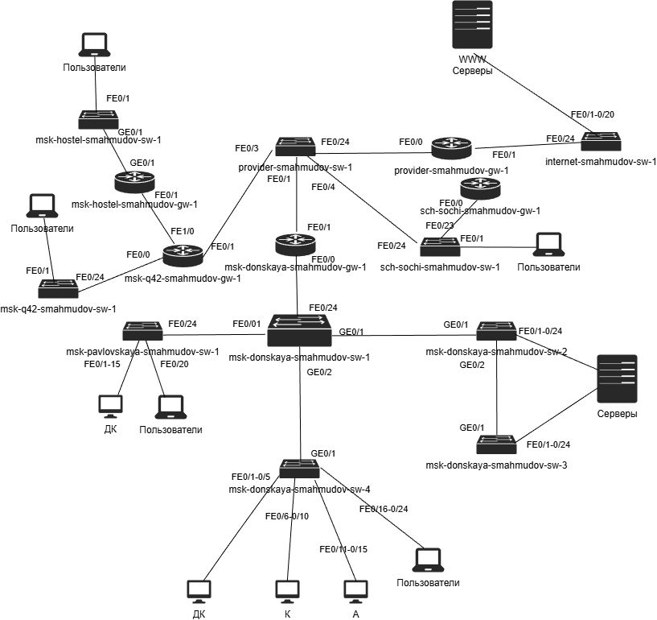

Схема L1 с физическими соединениями сети

## Схема L2: VLAN

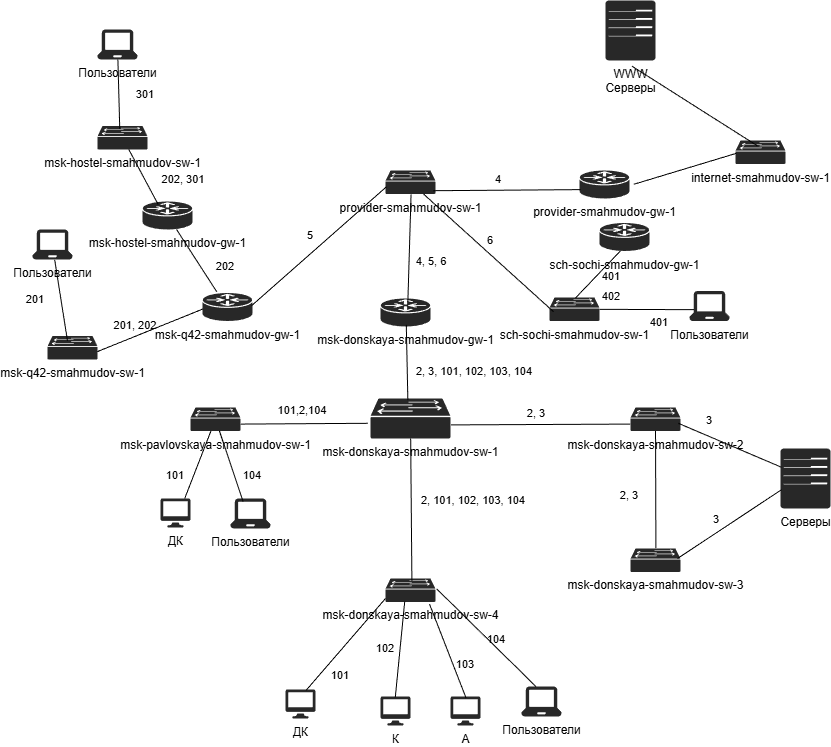

Схема L2 с VLAN сети

## Схема L3: IP-подсети

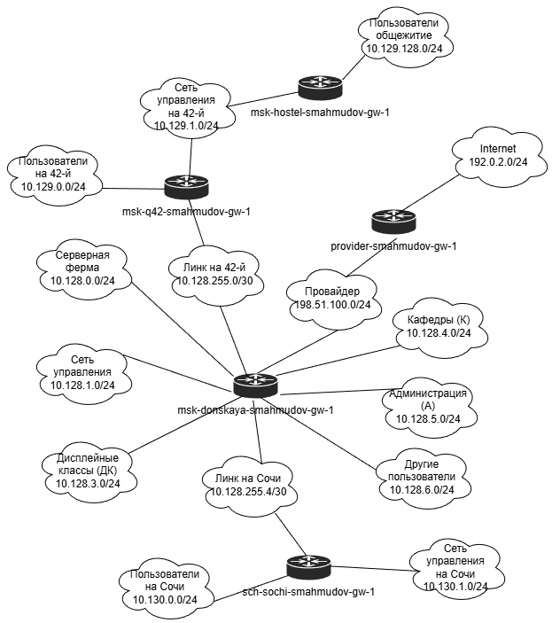

Схема L3 с IP-подсетями сети

## Дополнение проекта в Cisco Packet Tracer

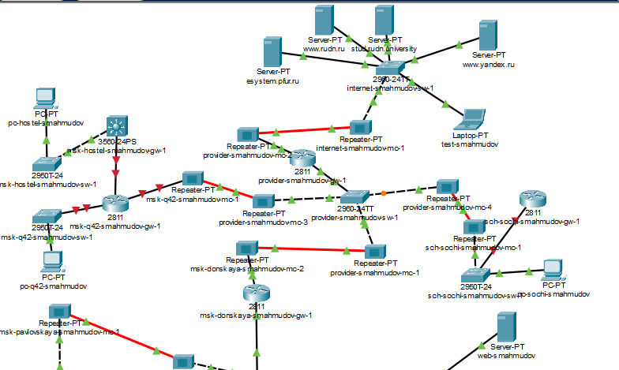

Дополненная логическая схема сети

## Физическое размещение площадок

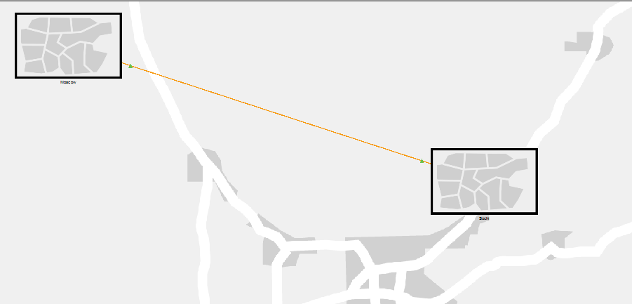

Физическая схема расположения площадок Moscow и Sochi

## Размещение оборудования в Москве

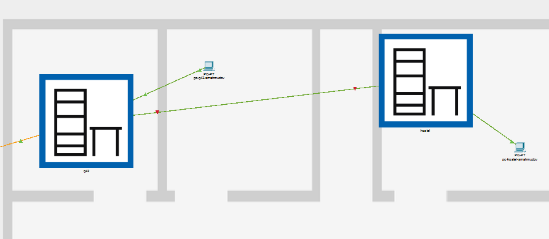

Физическое размещение оборудования на площадке Moscow

## Размещение оборудования в Сочи

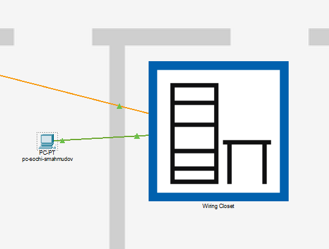

Физическое размещение оборудования филиала Sochi

## Настройка маршрутизатора 42-го квартала

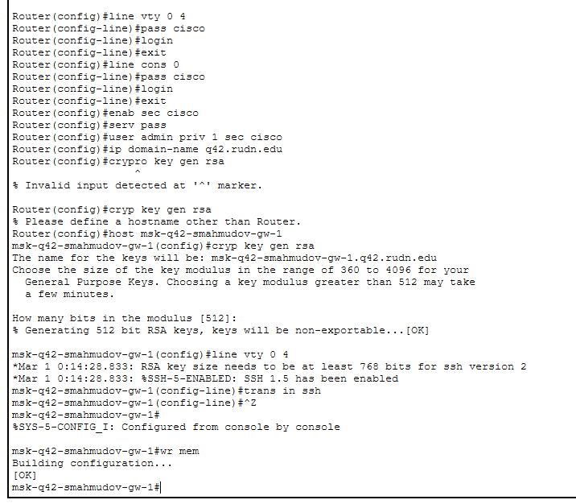

Первоначальная настройка маршрутизатора msk-q42-smahmudov-gw-1

## Настройка коммутатора 42-го квартала

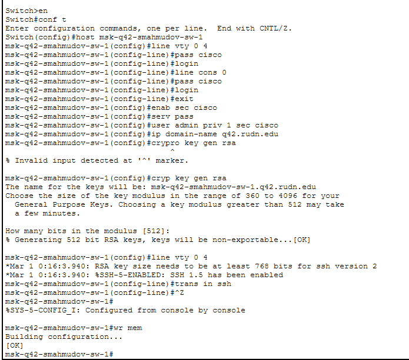

Первоначальная настройка коммутатора msk-q42-smahmudov-sw-1

## Настройка оборудования общежития

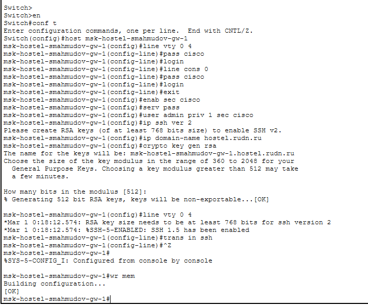

Первоначальная настройка устройства msk-hostel-smahmudov-gw-1

## Настройка коммутатора общежития

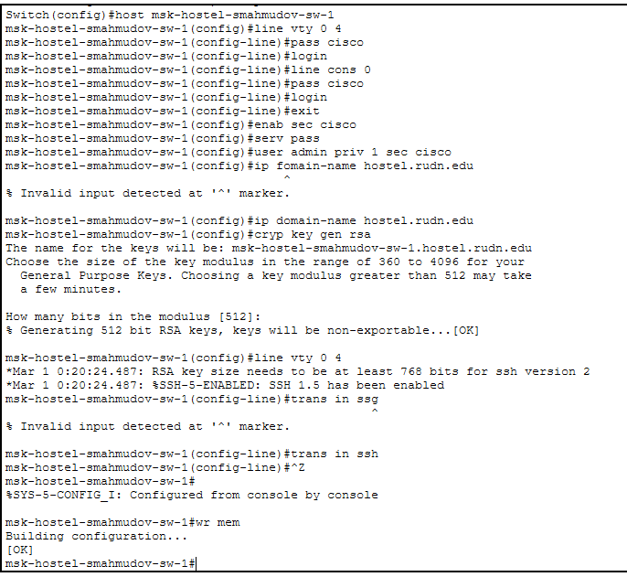

Первоначальная настройка коммутатора msk-hostel-smahmudov-sw-1

## Настройка коммутатора филиала

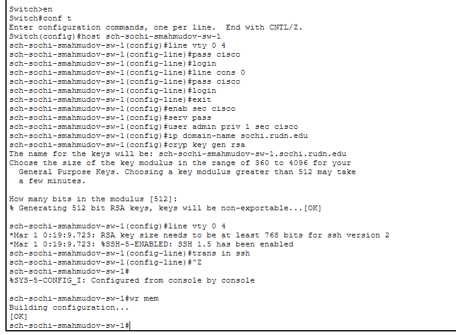

Первоначальная настройка коммутатора sch-sochi-smahmudov-sw-1

## Настройка маршрутизатора филиала

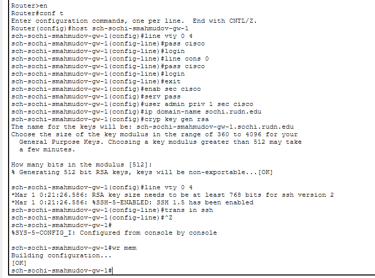

Первоначальная настройка маршрутизатора sch-sochi-smahmudov-gw-1

# Выводы по проделанной работе

## Вывод

- Схемы **L1**, **L2** и **L3** были дополнены сведениями о новых участках сети
- На L1 отображены физические соединения и интерфейсы
- На L2 указаны VLAN пользовательских и управляющих сегментов
- На L3 добавлены IP-подсети 42-го квартала и филиала в Сочи
- Выполнена первичная настройка добавленного оборудования
- Проект подготовлен к дальнейшей настройке статической маршрутизации